# 2_4_Numpy_Arrays

### Hazır Array Üretme Yönemleri

```python
#np.array([1,2,3,4,5], dtype=float) #float tipine çevirir.
np.arange(1,12,2) #1'den 10'a kadar 2'şer artarak dizi oluşturur. #range gibi çalışır.

#istenen boyuta çebirelim.
np.arange(1,12,2).reshape(2,3) #2x2'lik bir dizi oluşturur.

#
np.zeros((3,4)) #3x4'lük sıfırlardan oluşan bir dizi oluşturur.
np.ones((3,4),dtype=int) #3x4'lük birlerden oluşan bir dizi oluşturur.

#
np.eye(3, dtype=int) #3x3'lük birim matris oluşturur. köşegenler 1, diğerleri 0

#
np.full((3,4), 9) #3x4'lük 9'lardan oluşan bir dizi oluşturur.
```

```
array([[9, 9, 9, 9],
       [9, 9, 9, 9],
       [9, 9, 9, 9]])
```

### Matematiksel İşlemler

```python
x = np.array([2,4,6])
y = np.array([1,3,5])

#
np.add(x,y) #eleman bazında toplama yapar. aynı sıradaki elemanları toplar.
x + y #aynı işlemi yapar.

#
np.subtract(x,y) #eleman bazında çıkarma yapar. aynı sıradaki elemanları çıkarır.
x-y #aynı işlemi yapar.

#
np.multiply(x,y) #eleman bazında çarpma yapar. aynı sıradaki elemanları çarpar.
x*y #aynı işlemi yapar.

#
np.divide(x,y) #eleman bazında bölme yapar. aynı sıradaki elemanları böler.
x/y #aynı işlemi yapar.

#
np.square(x) #karelerini alır.
x**2 #karelerini alır.

#
np.sqrt(x) #karekökünü alır.
x**0.5 #2 #karelerini alır.
```

```
array([ 4, 16, 36])
```

```python
np.equal(x,y) #eleman bazında karşılaştırma yapar. aynı sıradaki elemanları karşılaştırır. geriye eleman eleman True, False döner.
np.array_equal(x,y) #dizilerin eşit olup olmadığını kontrol eder. tek bir True veya False döner
```

```
False
```

```python
#dot product: (matrislerde kullanılan bir tür çarpma işlemidir.)
x.dot(y) #2*1 + 4*3 + 6*5 = 2+12+30 = 44
#mesela 3x1'lik matris ile 1x3'lük matris çarpıldığında 3x3'lük bir matris oluşur.
```

```
44
```

### Matrisin Tersini Almak (inverse)

- matrisin kendisi ile inversünü çarparsak birim matris elde ederiz.
- Bir takım bilinmeyenlerin olduğu denkleri çözeren bu matris tersini kullanırız.

```python
m_dizi = np.arange(1,5).reshape(2,2) #1-5 arasındaki sayıları 2x2'lik bir diziye çevirir.
m_dizi
```

```
array([[1, 2],
       [3, 4]])
```

```python
m_dizi_inverse = np.linalg.inv(m_dizi) #matrisin tersini alır.
m_dizi_inverse
```

```
array([[-2. ,  1. ],
       [ 1.5, -0.5]])
```

#### Doğrudan matrix tanımlayıp matris cebiri ile çalışmak mümkün

```python
mtrs = np.matrix([(1,2),(3,4)]) #matrix tipine çevirir.
mtrs
```

```
matrix([[1, 2],
        [3, 4]])
```

```python
mtrs ** -1 #matrisin tersini alır.
```

```
matrix([[-2. ,  1. ],
        [ 1.5, -0.5]])
```

### Denklemlerdeki Bilinmeyenleri Bulalım

[figure not shown]

### Bazı Array Fonksiyonları

```python
dizi = np.arange(1,25).reshape(3,8)
dizi
```

```
array([[ 1,  2,  3,  4,  5,  6,  7,  8],
       [ 9, 10, 11, 12, 13, 14, 15, 16],
       [17, 18, 19, 20, 21, 22, 23, 24]])
```

```python
#axis verilebilir. Yani hangi boyutta işlem yapılacağını belirtebiliriz.
#axis=0 satırlar üzerinde işlem yapar.
#axis=1 sütunlar üzerinde işlem yapar.
dizi.sum() #tüm elemanların toplamını verir.

#
dizi.sum(axis=0) #satırlar üzerinde işlem yapar. satırları topla
dizi.sum(axis=1) #sütunlar üzerinde işlem yapar. sütunları topla

#min, max, mean, std, cumsum gibi fonksiyonlar da kullanılabilir.
```

```
array([ 36, 100, 164])
```

```python
#transpose
dizi.T #transpozunu alır. satırları sütun, sütunları satır yapar.
dizi.transpose()
```

```
array([[ 1,  9, 17],
       [ 2, 10, 18],
       [ 3, 11, 19],
       [ 4, 12, 20],
       [ 5, 13, 21],
       [ 6, 14, 22],
       [ 7, 15, 23],
       [ 8, 16, 24]])
```

```python
#diziyi tek boyuta indirgeyelim
dizi.reshape(1,24) #1 satır 24 sütun olacak şekilde yeniden şekillendirir.
dizi.ravel() #diziyi tek boyuta indirger.
```

```
array([ 1,  2,  3,  4,  5,  6,  7,  8,  9, 10, 11, 12, 13, 14, 15, 16, 17,
       18, 19, 20, 21, 22, 23, 24])
```

```python
np.insert(dizi, 0, -99) #dizinin başına -99 ekler.
np.delete(dizi,(1,2,3,4)) #dizinin 1,2,3,4. elemanlarını siler.
```

```
array([ 1,  6,  7,  8,  9, 10, 11, 12, 13, 14, 15, 16, 17, 18, 19, 20, 21,
       22, 23, 24])
```

```python
a = np.array([1,2,3])
b = np.array([4,5,6])

#
np.concatenate([a,b]) #dizileri birleştirir.

#
np.vstack([a,b]) #dizileri üst üste birleştirir. union
np.hstack([a,b]) #dizileri yan yana birleştirir. join gibi


#birleştirilem ve paraçalayalım
birlesmis = np.vstack([a,b])
print(birlesmis)

#
dikeyParcalaListesi = np.vsplit(birlesmis, 2) #2'ye böler.
print(dikeyParcalaListesi) #her parcayı liste elemanı olarak verdi. unpacking yöntemi ile alabilirsin.

yatayParcalaListesi = np.hsplit(birlesmis, 3) #3'e böler.
print(yatayParcalaListesi) #her parcayı liste elemanı olarak verdi. unpacking yöntemi ile alabilirsin.
print("ilk yatay parça :",yatayParcalaListesi[0])
```

```
[[1 2 3]
 [4 5 6]]
[array([[1, 2, 3]]), array([[4, 5, 6]])]
[array([[1],
       [4]]), array([[2],
       [5]]), array([[3],
       [6]])]
ilk yatay parça : [[1]
 [4]]
```

#### Numpy Elemanlarına Erişmek

- Subsetting
- Slicing
- Fancy Indexing
- Boolean Indexing

```python
a = np.arange(0,30).reshape(6,5)
a
```

```
array([[ 0,  1,  2,  3,  4],
       [ 5,  6,  7,  8,  9],
       [10, 11, 12, 13, 14],
       [15, 16, 17, 18, 19],
       [20, 21, 22, 23, 24],
       [25, 26, 27, 28, 29]])
```

#### Subsetting

```python
#tek boyutta filtreleme
a[3] #ilk boyuttan 3. indextekini getir. 3. indexteki satırı getirir.
a[-2] #sondan 2. indexteki satırı getirir.

#iki boyutta filtreleme
a[3][4] #3. satırın 4. sütunundaki elemanı getirir.
a[3,4] #3. satırın 4. sütunundaki elemanı getirir.
```

```
19
```

#### Slicing

- `array[start:stop:step , start:stop:step, start:stop:step]` şeklinde kullanılır.

```python
a[1:3 , 2:4] #1. ve 2. satırların 2. ve 3. sütunları arasındaki elemanları getirir.
```

```
array([[ 7,  8],
       [12, 13]])
```

```python
#soru:
'''
    1. Boyut:
        2-5 arsını 3'er atla getir.
    2. Boyut:
        1-4 arasını 2'şer atla getir.
'''
a[2:5:3, 1:4:2]
```

```
array([[11, 13]])
```

```python
#başkangıç belirtilmezse en baştan, bitiş belirtilmese en sona gider.
#-1 tersten anlamına gelir.
a[:2, :-1] #ilk iki satırın son sütun hariç tüm sütunlarını getirir.

#
a[:,::-1] #tüm satırların sütunlarını tersten getirir. resmin aynadaki yansıması gibi.
a[::-1,::-1] #hem satırları hem sütunları tersten getirir. resmi 180 derece döndürmüş oluruz. saat yönünün tersine döndürmüş oluruz.
```

```
array([[29, 28, 27, 26, 25],
       [24, 23, 22, 21, 20],
       [19, 18, 17, 16, 15],
       [14, 13, 12, 11, 10],
       [ 9,  8,  7,  6,  5],
       [ 4,  3,  2,  1,  0]])
```

#### Indexing

[figure not shown]

```python
a[ (1,3) , (2,4)]

#iki eleman gelecek:
#birinci boyutta 1. index ile ikinci boyutta 2. indexi getirir.
#birinci boyutta 3. index ile ikinci boyutta 4. indexi getirir.
```

```
array([ 7, 19])
```

#### Boolean Indexing

- True/False dizisi filtre olarak kullanılır. True ile eşleşen elemanlar alınır.

```python
#broadcast
a < 5 #her bir elemanı 5 ile karşılaştırır. True veya False döner.
```

```
array([[ True,  True,  True,  True,  True],
       [False, False, False, False, False],
       [False, False, False, False, False],
       [False, False, False, False, False],
       [False, False, False, False, False],
       [False, False, False, False, False]])
```

```python
#örn:
#3'e tam bölünenleri bulalım.
filtre_uce_bolunenler = a % 3 == 0 #True/False matrisi döner.

#
a[filtre_uce_bolunenler] #3'e tam bölünenleri getirir.
```

```
array([ 0,  3,  6,  9, 12, 15, 18, 21, 24, 27])
```

#### Mantıksal Operatorler

- `np.logical_not(TFDizisi)` veya `~TFDizisi` ile **not** yapılablir. yani tüm mantıksal sonuçların tersini verir.
- `np.logical_and` veya `&` ile **and**
- `np.logical_or` veya `|` ile **or**

```python
#örn:
#hem 2'ye hem 3'e tam bölünenleri bulalım.

#
filtre_3 = a%3==0
filtre_2 = a%2==0

#
filtre = np.logical_and(filtre_2, filtre_3) #iki filtrede True olanları getirir.
#filtre = filtre_2 & filtre_3 #aynı işlemi yapar.

#
a[filtre]
```

```
array([ 0,  6, 12, 18, 24])
```

#### Where şarta uyanlar ve uymayanlar için işlem yapma imkanı sağlar.

- şarta uyanlar için bir değer, uymayanlar için başka bir değer döndürür.
- `np.where(condition, şartaUyanlar, şartaUymayanlar)` şeklinde kullanılır.

```python
np.where(a%2==0, "çift", "tek") #çift ise çift, değilse tek yazdırır.
```

```
array([['çift', 'tek', 'çift', 'tek', 'çift'],
       ['tek', 'çift', 'tek', 'çift', 'tek'],
       ['çift', 'tek', 'çift', 'tek', 'çift'],
       ['tek', 'çift', 'tek', 'çift', 'tek'],
       ['çift', 'tek', 'çift', 'tek', 'çift'],
       ['tek', 'çift', 'tek', 'çift', 'tek']], dtype='<U4')
```

### Numpy ile Okuma Yazma

##### Binary

```python
np.save("./databases/dizi_binary",a) #diziyi binary olarak kaydeder.
```

```python
np.load("./databases/dizi_binary.npy") #diziyi yükler.
```

```
array([[ 0,  1,  2,  3,  4],
       [ 5,  6,  7,  8,  9],
       [10, 11, 12, 13, 14],
       [15, 16, 17, 18, 19],
       [20, 21, 22, 23, 24],
       [25, 26, 27, 28, 29]])
```

##### Text

```python
np.savetxt("./databases/dizi_text.txt",a,delimiter=",") #diziyi text olarak kaydeder.
```

```python
np.loadtxt("./databases/dizi_text.txt",delimiter=",") #diziyi yükler.
```

```
array([[ 0.,  1.,  2.,  3.,  4.],
       [ 5.,  6.,  7.,  8.,  9.],
       [10., 11., 12., 13., 14.],
       [15., 16., 17., 18., 19.],
       [20., 21., 22., 23., 24.],
       [25., 26., 27., 28., 29.]])
```

```python
#Soru:
'''
    1'lerden oluşan 10x10'luk bir dizi tanımlayalım.
    içine 8'lerden oluşan bir 6x6 lık kare çizelim
    karenin içinde yine 1'ler olsun.
'''
img=np.ones((10,10),dtype=int)

#
img[2:-2 , 2:-2] = 8
img[3:-3 , 3:-3] = 1

#
img
```

```
array([[1, 1, 1, 1, 1, 1, 1, 1, 1, 1],
       [1, 1, 1, 1, 1, 1, 1, 1, 1, 1],
       [1, 1, 8, 8, 8, 8, 8, 8, 1, 1],
       [1, 1, 8, 1, 1, 1, 1, 8, 1, 1],
       [1, 1, 8, 1, 1, 1, 1, 8, 1, 1],
       [1, 1, 8, 1, 1, 1, 1, 8, 1, 1],
       [1, 1, 8, 1, 1, 1, 1, 8, 1, 1],
       [1, 1, 8, 8, 8, 8, 8, 8, 1, 1],
       [1, 1, 1, 1, 1, 1, 1, 1, 1, 1],
       [1, 1, 1, 1, 1, 1, 1, 1, 1, 1]])
```

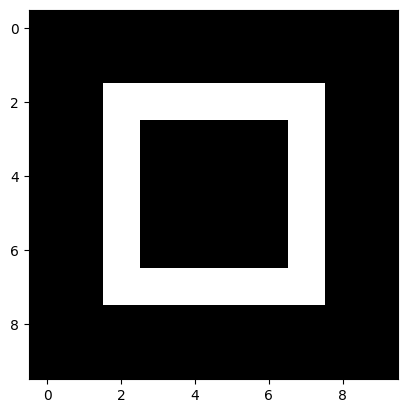

```python
import matplotlib.pyplot as plt

plt.imshow(img, cmap="gray")
plt.show()
```

Soru:

1. Aşağıdaki 2 boyutlu bir dizi tanımlayalım.
2. Truncu
3. Mavi Çizgili
4. Kırmızı
5. Mavi alanları getirelim.

[figure not shown]